# Chapter 1: Introduction to Time Series

← Back to the SCIM311 course page

[View the runnable R examples on GitHub](https://github.com/WJ-Mim/SCIM311-Statistical-Modelling/blob/main/LectureNote/r_examples/chapter01_intro_examples.R)

[Open the Chapter 1 live teaching demo](https://github.com/WJ-Mim/SCIM311-Statistical-Modelling/blob/main/LectureNote/live_demos/chapter01_live_demo.Rmd)

## How to Read This Chapter

This chapter starts with a simple question:

> What changes when data are ordered in time?

In ordinary regression, we often treat rows as separate observations. In time series, the order matters. Yesterday may affect today, this month may resemble last month, and a shock may continue to influence future observations.

Keep this idea in mind throughout the chapter:

- A time series is not just a column of numbers.
- The timing of the observations is part of the information.
- A good time series model should explain both the level of the series and how values depend on nearby values.

By the end of the chapter, the main goal is to look at a data set and decide whether it should be treated as cross-sectional data or time series data.

# 1. What is a Time Series?

We begin by comparing two familiar data layouts.

The first table measures several individuals at one time. The second table follows one quantity repeatedly over time. The numbers may look similar, but the modelling questions are different.

| Student | Height (cm) | Weight (kg) | GPA |
| --- | --- | --- | --- |
| S1 | 165 | 58 | 2.8 |
| S2 | 170 | 65 | 3.5 |
| S3 | 160 | 55 | 2.9 |
| S4 | 175 | 72 | 3.8 |
| S5 | 168 | 60 | 3.1 |
| S6 | 172 | 68 | 3.6 |
| S7 | 158 | 54 | 2.7 |
| S8 | 180 | 75 | 3.9 |
| S9 | 169 | 62 | 3.3 |
| S10 | 162 | 57 | 3.0 |

| Semester | GPA |
| --- | --- |
| 1 | 2.8 |
| 2 | 3.0 |
| 3 | 3.2 |
| 4 | 3.4 |
| 5 | 3.5 |
| 6 | 3.6 |
| 7 | 3.7 |
| 8 | 3.8 |

## 1.1 Cross-Sectional and Time Series Data

When we collect data, it is important to recognize whether the information comes from a single point in time or from repeated observations over time. This tells us how to analyze the data and what kinds of questions we can answer. Broadly, we separate data into two main types:

- **Cross-Sectional Data:** Observations on many entities at a single point in time. The ordering (if any) is usually not inherently meaningful.
- *Example*: Data of 10 students in Semester 1

| Student | Height (cm) | Weight (kg) | GPA |
| --- | --- | --- | --- |
| S1 | 165 | 58 | 2.8 |
| S2 | 170 | 65 | 3.5 |
| S3 | 160 | 55 | 2.9 |
| S4 | 175 | 72 | 3.8 |
| S5 | 168 | 60 | 3.1 |
| S6 | 172 | 68 | 3.6 |
| S7 | 158 | 54 | 2.7 |
| S8 | 180 | 75 | 3.9 |
| S9 | 169 | 62 | 3.3 |
| S10 | 162 | 57 | 3.0 |

[figure not shown]

cs.png

*This is cross-sectional: many subjects (students), measured once.*

- **Time Series Data:** Observations on a single entity or a few entities collected over multiple time periods. The ordering of observations is crucial.
- *Example*: Student S1 GPA over 8 semesters of study

| Semester | GPA |
| --- | --- |
| 1 | 2.8 |
| 2 | 3.0 |
| 3 | 3.2 |
| 4 | 3.4 |
| 5 | 3.5 |
| 6 | 3.6 |
| 7 | 3.7 |
| 8 | 3.8 |

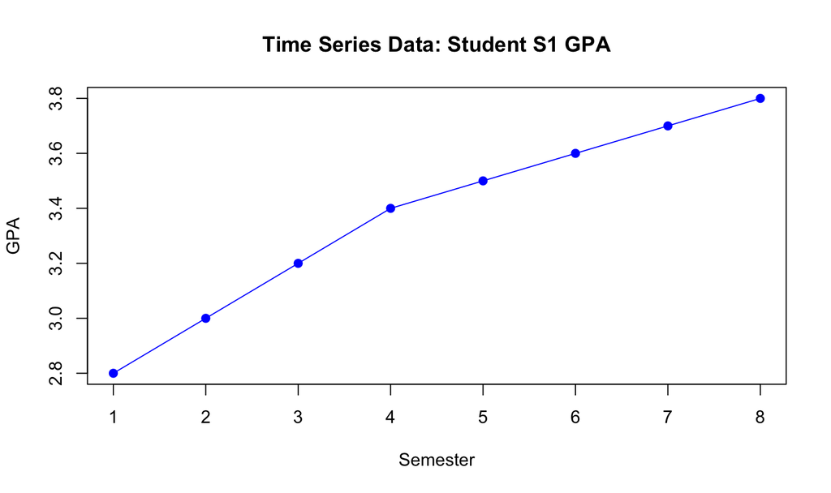

Rplot.png

*This is time series: one subject (student S1), measured repeatedly over time.*

GLMs typically focus on relationships in cross-sectional data or panel data where time might be a covariate but not necessarily the primary structural element as in time series modeling.

In the second part of this course, we are interested in **Time Series data**.

📌

**Definition:** A **time series** is a sequence of data points indexed, ordered, or graphed in time. Typically, a time series is a sequence of observations taken at successive equally spaced points in time.

$$X = \lbrace X_t : t = 1,2,3,\dots \rbrace.$$

**Examples:**

- **Finance:** Daily closing stock prices (e.g., MSFT), monthly S&P 500 index.
- **Economics:** Quarterly Gross Domestic Product (GDP), monthly unemployment rates.
- **Industry:** Hourly production volume from a factory, daily website traffic, minute-by-minute sensor readings from equipment.
- **Environment:** Daily maximum temperatures, annual CO2 concentrations.
- **Healthcare:** Hourly patient heart rate, weekly new flu cases.

## **1.2 Objectives of Time Series Analysis**

1. **Description/Understanding:** Identify patterns, components (trend, seasonality), and outliers to understand the underlying generating process.
2. **Modeling:** Develop a statistical model that adequately describes the observed data and its dependencies. This often involves estimating parameters of the model.
3. **Forecasting:** Predict future values of the time series based on past observations and the fitted model. This is a primary goal in many applications.

✂️

A **forecast** is a prediction of some future event(s).

A forecast can be:

- A **point forecast**: a single best estimate of the future value.
- Or a **prediction interval (PI)**: ****a range indicating the uncertainty around that forecast, which is more informative for decision-making.

There are two key design aspects:

- **Forecast horizon:** how far ahead we predict (e.g., 3 months).
- **Forecast interval:** how often forecasts are updated (e.g., monthly).
- **Short-term**: hours, days, weeks. Based on modeling and extrapolating data patterns.
- **Medium-term**: one to two years ahead.
- **Long-term**: several years into the future.

When forecasts are revised each period for the next $T$ periods, this is called a **rolling or moving horizon forecast** which is common in business and production planning.

### **Quantitative Forecasting Methods**

Quantitative forecasting methods make formal use of historical data through a forecasting model. These models summarise patterns in the data and describe statistical relationships between past and current values, allowing us to extrapolate these patterns into the future.

- **Regression methods**: make use of relationship between the variable of interest and predictors, e.g. forecast sales of one product by using purchases of other products.

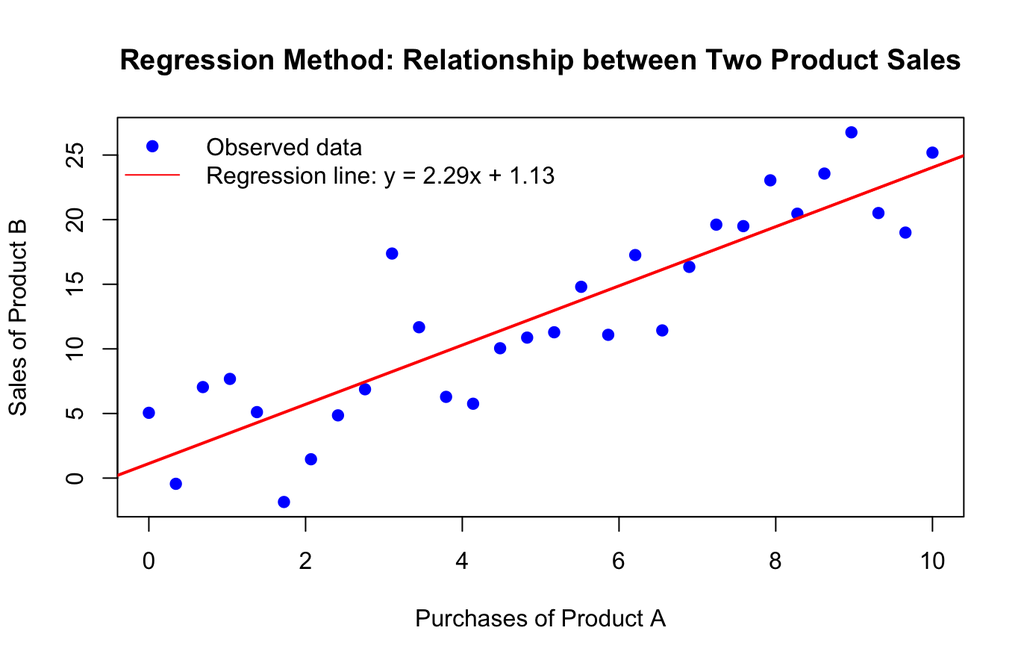

Fig_Ch1Reg.png

Sometimes regression models are called *causal forecasting models*, because the predictor variables are assumed to describe the forces that cause or drive the observed values of the variable of interest.

- **Smoothing methods:** use a simple function of previous observations to provide a forecast of the variable of interest (the response). For example,

$$\hat{y}_t = \frac{(y_{t-1} + y_{t-2} + y_{t-3} + y_{t-4})}{4}$$

or

$$\hat{y}_t = 0.4y_{t-1} + 0.3y_{t-2} + 0.2y_{t-3} + 0.1y_{t-4}$$

Note: $\hat{y}_t$ is the forecast of $y$ at time $t$, and $y_{t-i}$ is the actual value of $y$ at time $t-i$, where $i = 1, 2, 3, 4$.

They are easy to apply and give good results even with minimal theory.

- **Formal time series analysis methods:** use statistical properties of historical data (e.g., ARIMA) and estimate unknown parameters from past observations. ****

# 2. Components of a Time Series

Time series plots can reveal patterns such as random, trends, level shifts, periods or cycles,unusual observations,or a combination of patterns. Patterns commonly found in time series data are:

- **Trend ($T_t$):** The long-term general direction or movement of the series. It can be upward, downward, or stable.
- **Seasonality ($S_t$):** Patterns that repeat over a fixed period of time (e.g., daily, weekly, monthly, quarterly, yearly). These are usually caused by factors like weather, holidays, or social customs.
- **Cyclical ($C_t$):** Long-term wavelike fluctuations around the trend, which are not of a fixed period. These are often associated with business cycles or other longer economic/environmental phenomena. Cycles are generally harder to model than seasonality due to their variable duration and magnitude.
- *Example:* The unemployment rate rises and falls over multi-year intervals, following economic cycles: recessions and recoveries.
- **Irregular/Random Component ($\epsilon_{t}$):** The unpredictable, random fluctuations or “noise” in the series after all other components have been accounted for. It’s what remains unexplained.

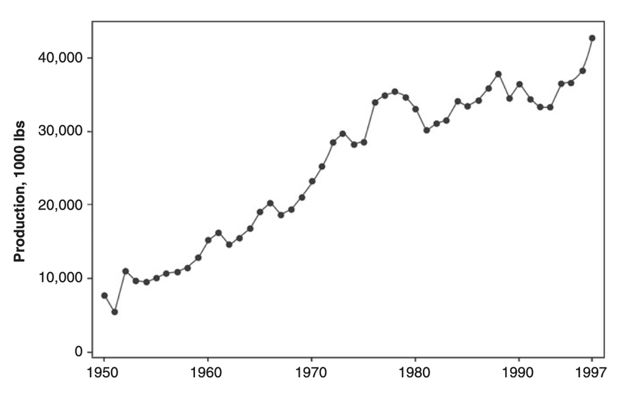

The US annual production of blue and gorgonzola cheeses. USDA–NASS. Reference: Introduction to Time Series Analysis and Forecasting, MJK

The US annual production of blue and gorgonzola cheeses. USDA–NASS. Reference: Introduction to Time Series Analysis and Forecasting, MJK

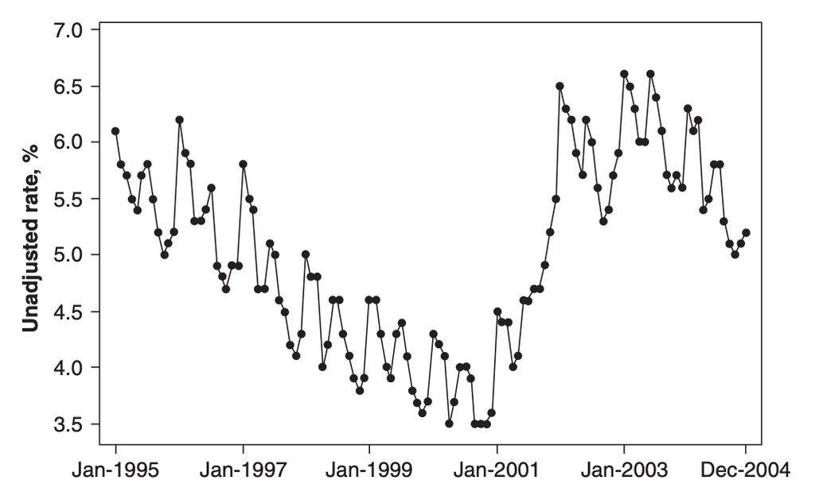

Monthly unemployment rate—full-time labor force. Reference: Introduction to Time Series Analysis and Forecasting, MJK

Monthly unemployment rate—full-time labor force. Reference: Introduction to Time Series Analysis and Forecasting, MJK

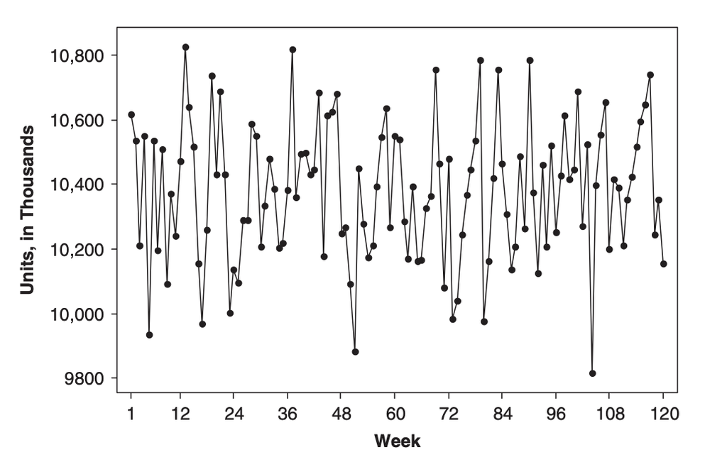

Pharmaceutical product sales. Reference: Introduction to Time Series Analysis and Forecasting, MJK

Pharmaceutical product sales. Reference: Introduction to Time Series Analysis and Forecasting, MJK

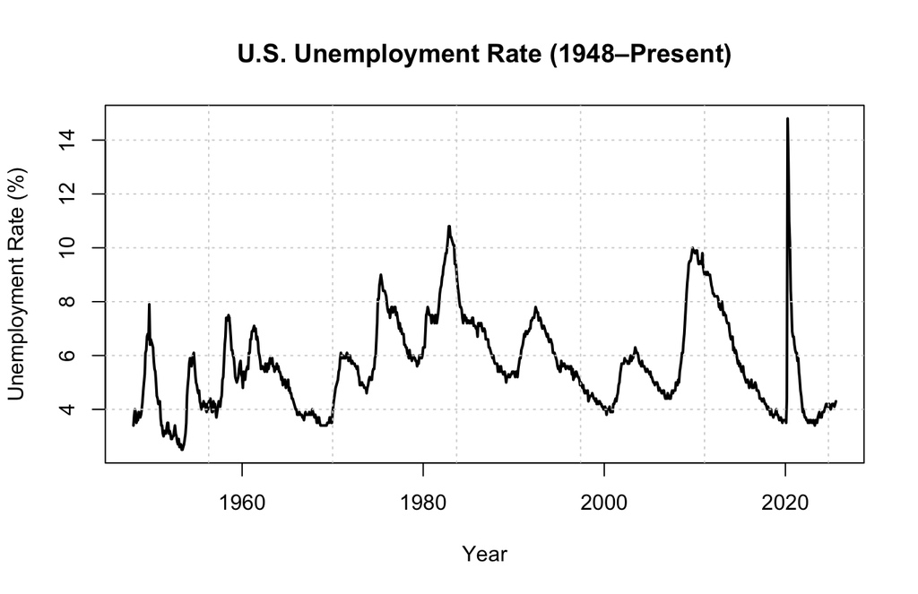

U.S. unemployment rate from FRED using library(quantmod)

U.S. unemployment rate from FRED using library(quantmod)

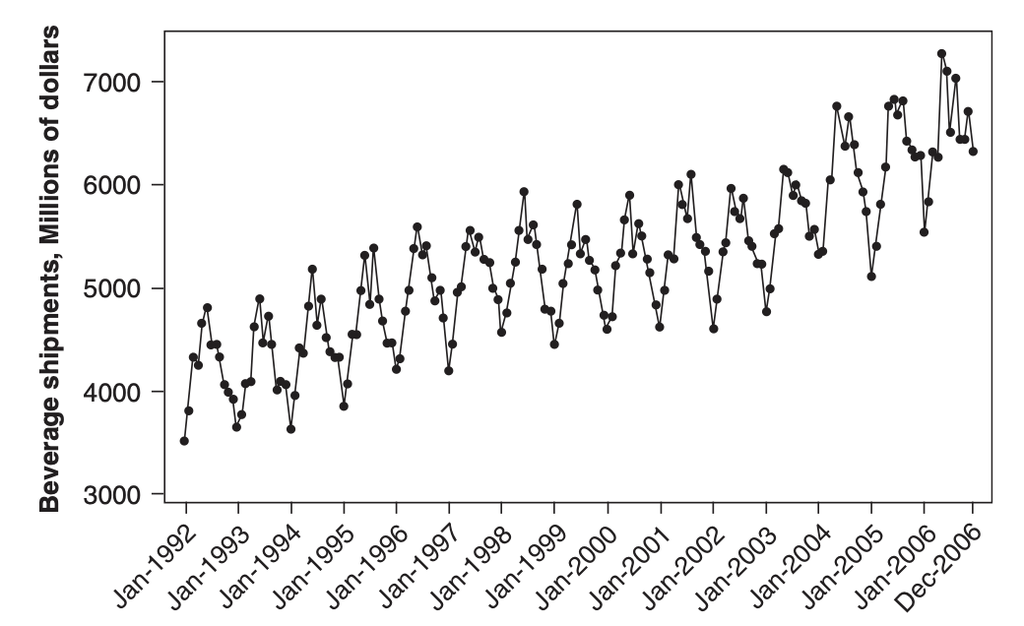

The US beverage manufacturer monthly product shipments Reference: Introduction to Time Series Analysis and Forecasting, MJK

The US beverage manufacturer monthly product shipments Reference: Introduction to Time Series Analysis and Forecasting, MJK

**Decomposition Models:**

- **Additive Model:** $Y_t = T_t + S_t + C_t + \epsilon_{t}$

Assumes the magnitude of seasonality and random fluctuations is constant regardless of the level of the trend.

- **Multiplicative Model:** $Y_t = T_t \times S_t \times C_t \times \epsilon_{t}$

Assumes the magnitude of seasonality and random fluctuations varies proportionally with the level of the trend. Often, a log transformation can convert a multiplicative relationship to an additive one:

$$\log(Y_t) = \log(T_t) + \log(S_t) + \log(C_t) + \log(\epsilon_t).$$

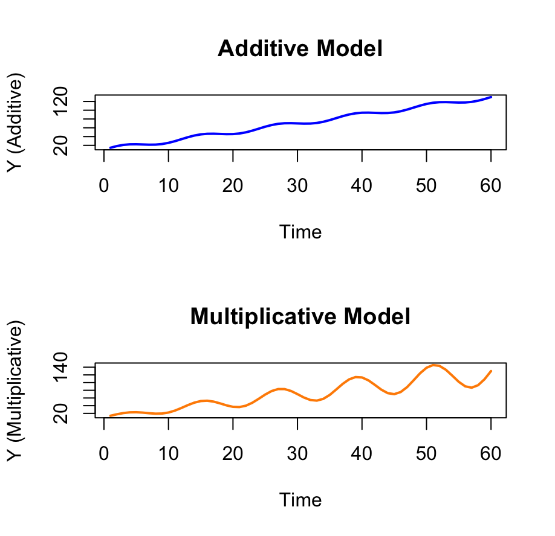

Rplot02.png

```r
    t <- 1:60
    trend <- 10 + 2*t
    season <- sin(2*pi*t/12)

    # Additive model
    Y_add <- trend + 5 * season

    # Multiplicative model
    Y_mul <- trend * (1 + 0.3 * season)

    par(mfrow=c(2,1))
    plot(t, Y_add, type="l", col="blue", lwd=2,
         main="Additive Model",
         ylab="Y (Additive)", xlab="Time")
    plot(t, Y_mul, type="l", col="darkorange", lwd=2,
         main="Multiplicative Model",
         ylab="Y (Multiplicative)", xlab="Time")
    par(mfrow=c(1,1))
```

# 3. **Some Simple Time Series Models**

An essential part of time series analysis is selecting a suitable probabilistic model to represent the data. We assume that each observed value $x_t$ is a realization of a random variable $X_t$.

A **time series model** specifies the joint distributions(or at least the mean and covariance structure) of these random variables.

In practice, we rarely specify full joint distributions. Instead, we focus on second-order properties i.e., ****means, variances, and covariances which are sufficient for describing linear dependence and for building forecasting models

### **3.1 Zero-Mean Models**

1. **IID Noise** The simplest possible time series mode**l** assumes:
- No trend or seasonality, and
- Each observation $X_t$ is **independent and identically distributed (iid)** with mean $0$.

Formally,

$$\Pr(X_1 \le x_1, \dots, X_n \le x_n) = \prod_{i=1}^n F(x_i),$$

where $F(\cdot)$ is the common cumulative distribution function of all $X_t$.

This means:

- There is **no dependence** between observations.
- Knowing past values $X_1, \dots, X_n$ tells you nothing about future ones $X_{n+h}$.
- The optimal forecast of any future value (in the mean-square sense) is simply **0**.

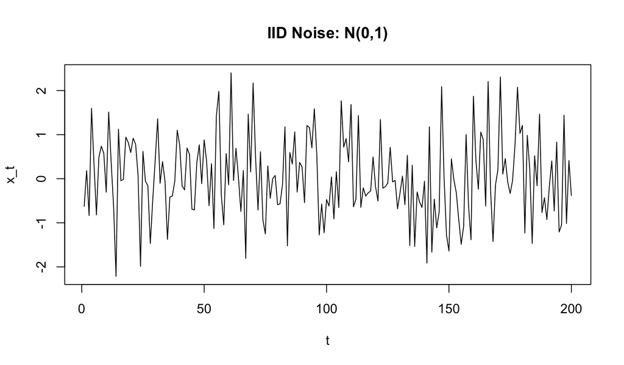

Fig_Ch1noise.png

```r
            set.seed(1)
            n <- 200
            x <- rnorm(n, mean = 0, sd = 1)  # iid N(0,1)
            plot(ts(x), main = "IID Noise: N(0,1)", ylab = "x_t", xlab = "t")
```

2. **Binary Process**

A simple discrete-valued iid process:

$P[X_t = 1] = p, P[X_t = -1] = 1 - p$

For $p = 0.5$, this corresponds to fair coin tosses (+1 for heads, -1 for tails).

Although simple, it can model two-state processes (e.g., wins/losses in baseball).

3. **Random Walk**

The **random walk** is a cumulative sum of iid noise:

$$S_t = X_1 + X_2 + \cdots + X_t$$

or recursively, $S_t = S_{t-1} + X_t$.

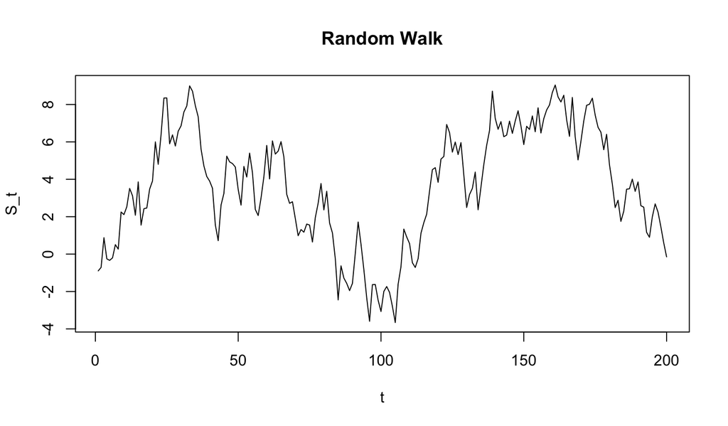

Fig_Ch1RW.png

```r
        set.seed(2)
        n <- 200
        eps <- rnorm(n, 0, 1)
        S <- cumsum(eps)              # random walk: S_t = S_{t-1} + eps_t
        plot(ts(S), main = "Random Walk", ylab = "S_t", xlab = "t")
```

❓

What is the mean and variance of $S_t$?

For the random walk $S_t=X_1+\cdots+X_t$, if the increments are independent with $\text{E}(X_i)=0$ and $\text{Var}(X_i)=\sigma^2$, then

$$\text{E}(S_t)=0,
\qquad
\text{Var}(S_t)=t\sigma^2.$$

Use this answer to emphasise the main idea: the average position stays centred around zero, but the uncertainty grows with time. This is why a random walk does not behave like a stationary series.

### **3.2 Models with Trend**

Many real series exhibit **deterministic components**, such as trend or periodicity.

We can represent such data as:

$$X_t = m_t + Y_t$$

where $m_t$ is a deterministic **trend** component and $Y_t$ is a stochastic component which has zero mean. A **polynomial trend** model can be written as:

$$m_t = a_0 + a_1t + a_2t^2 + \cdots + a_kt^k$$

Parameters $a_0, a_1, \dots, a_k$ are typically estimated using **least squares regression**.

**Example: Level of Lake Huron (1875–1972)**

The dataset LakeHuron in R records annual water levels (in feet) of Lake Huron from 1875 to 1972.

Since the lake level declines approximately linearly with time, the model fitted is

$$X_t = a_0 + a_1 t + Y_t, \quad t = 1, \dots, 98,$$

where $Y_t$ represents the stochastic (noise) component.

The **least-squares estimates** reported are $\hat{a}_0 = 10.202, \hat{a}_1 = -0.0242$.

Thus the fitted trend line is

$$\hat{X}_t = 10.202 - 0.0242t.$$

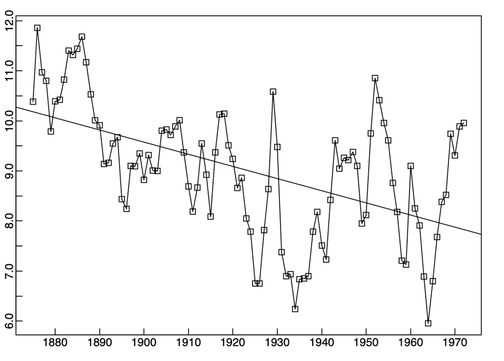

image.png

### **3.3 General Approach to Time Series Modelling**

1. **Plot the data.** Observe trend, seasonality, sudden changes, or outliers.
2. **Transform the data** (e.g., log) if variance grows with level.
3. **Remove trend/seasonality** via regression or differencing.
4. **Model residuals** using ACF/PACF to identify AR, MA, or ARMA structure.
5. **Forecast and reconstruct** the original series by adding back the trend and seasonal components.

# 4. Visualizing Time Series

- **Time Plot:** The most fundamental tool.
- Plots observations against time.
- Helps to visually identify:
- Trends (upward, downward, flat).
- Seasonality (repeating patterns).
- Cycles (longer-term waves).
- Outliers (unusual points).
- Changes in variance (heteroscedasticity).
- Structural breaks (sudden changes in the pattern).
- **R for Plotting:**
- Base R `plot()`:

```r
        # Assuming 'my_ts_data' is a time series object

        plot(my_ts_data, main="Time Plot of My Data", ylab="Value", xlab="Time")
```

**Example**:

- The built-in dataset AirPassengers is a `ts` (time series) object.

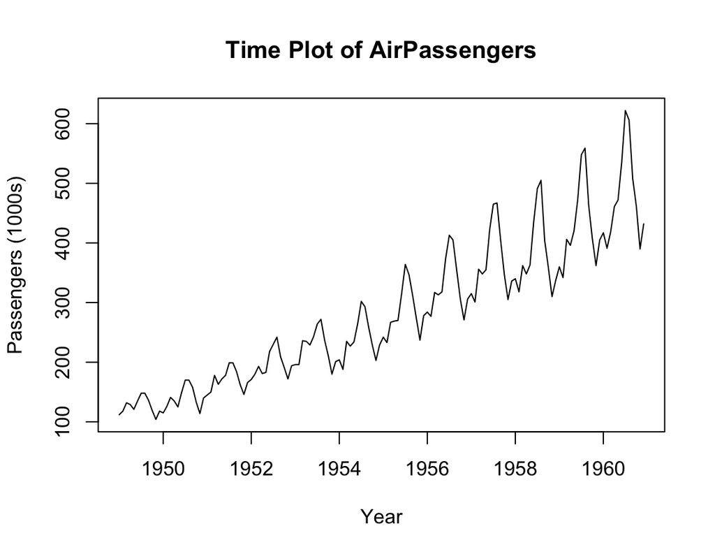

plot(Air).png

```r
        # Example using built-in AirPassengers data
        my_ts_data <- AirPassengers

        # Create a simple time series plot
        plot(my_ts_data,
             main = "Time Plot of AirPassengers",
             ylab = "Passengers (1000s)",
             xlab = "Year")
```

- `ggplot2` for more advanced graphics:

```r
        install.packages("ggplot2")

        library(ggplot2)

        # Assuming 'df' is a data frame with 'Date' and 'Value' columns
        df$Date <- as.Date(df$Date)     # Ensure Date is in Date format

        # ggplot and add layers
        ggplot(df, aes(x=Date, y=Value)) +
               geom_line() +
               labs(title="Time Plot using ggplot2", x="Date", y="Value") +
               theme_minimal()
```

1. `geom_line()` how to plot the data.
2. `labs()` labels the plot.
3. `theme()` customizes style and layout.
4. `scale_x_date()` formats the axis nicely.

**Example:**

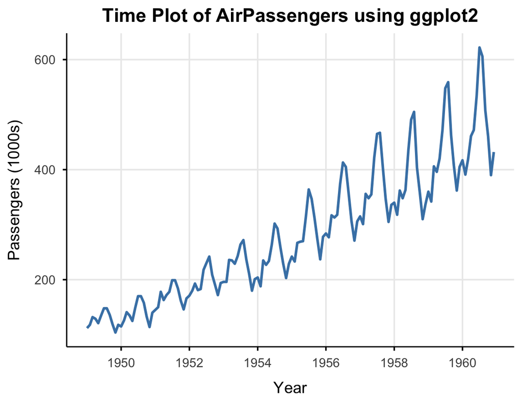

ggplot(Air).png

```r
        # Convert AirPassengers to data frame with two columns: date and value
        df <- data.frame(
          Date  = seq(as.Date("1949-01-01"), by = "month", length.out = length(AirPassengers)),
          Value = as.numeric(AirPassengers)
        )

        # ggplot
        ggplot(df, aes(x = Date, y = Value)) +
          geom_line(color = "steelblue", linewidth = 1) +
          labs(
            title = "Time Plot of AirPassengers using ggplot2",
            x = "Year",
            y = "Passengers (1000s)"
          ) +
          theme_minimal(base_size = 13) +
          theme(
            plot.title = element_text(hjust = 0.5, face = "bold"),  # center the title
            axis.title.x = element_text(margin = margin(t = 10)),   # space below x-label
            axis.title.y = element_text(margin = margin(r = 10)),   # space beside y-label
            panel.grid.minor = element_blank(),                     # cleaner grid
            axis.line = element_line(color = "black", linewidth = 0.5),
            axis.ticks = element_line(color = "black")
          ) +
          scale_x_date(date_breaks = "2 years", date_labels = "%Y")
```

# 5. Basic Time Series Objects in R

A *time series* in R is more than a list of numbers —

it’s a numeric sequence **with time context** (start, frequency, and order).

> Vectors just store numbers. Time series objects remember *when* each number happened. - **`ts()` function:** Creates a time series object in R. - **Key arguments:** - `data`: A numeric vector or matrix of the observed values. - `start`: The time of the first observation. Can be a single number (e.g., year) or a vector of two numbers (e.g., `c(year, period_within_year)` like `c(2020, 1)` for Jan 2020 if frequency is 12). - `end`: The time of the last observation. - `frequency`: The number of observations per unit of time (e.g., 1 for annual, 4 for quarterly, 12 for monthly, 52 for weekly, 365.25 for daily). - **Example:**

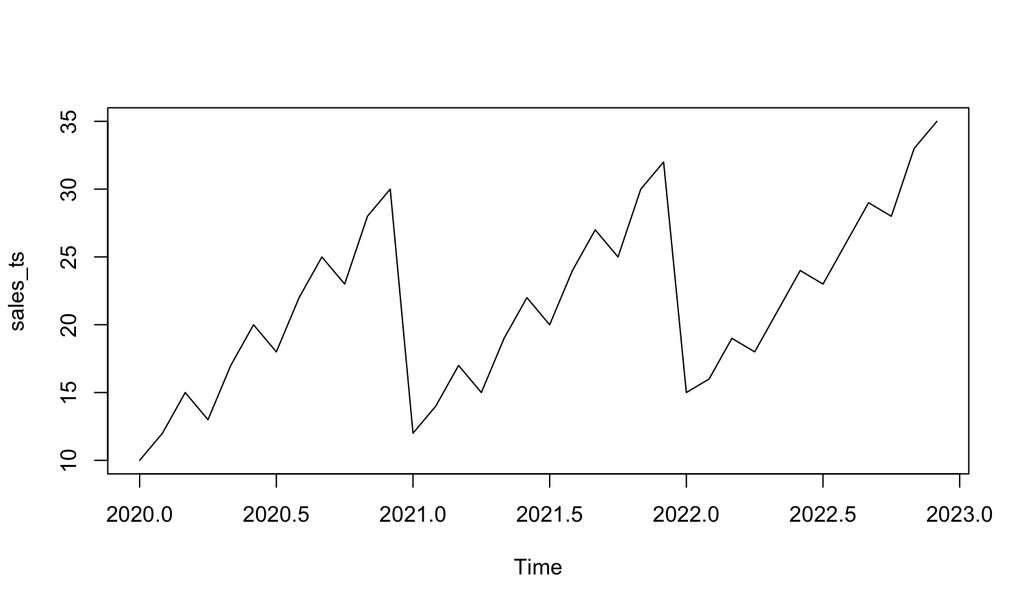

ts.png

```r
        # Create a simple vector called sales_data
        sales_data <- c(10, 12, 15, 13, 17, 20, 18, 22, 25, 23, 28, 30,
                        12, 14, 17, 15, 19, 22, 20, 24, 27, 25, 30, 32,
                        15, 16, 19, 18, 21, 24, 23, 26, 29, 28, 33, 35)

        # Create a time series object, monthly data starting from Jan 2020 for 3 years
        sales_ts <- ts(sales_data, start=c(2020, 1), frequency=12)
        print(sales_ts)
        plot(sales_ts)
```

- **Decomposition using `decompose()` and `stl()`:**
- **`decompose(ts_data, type="additive" or "multiplicative")`:** Classical decomposition method. Simple but can be naive, especially at the ends of the series.

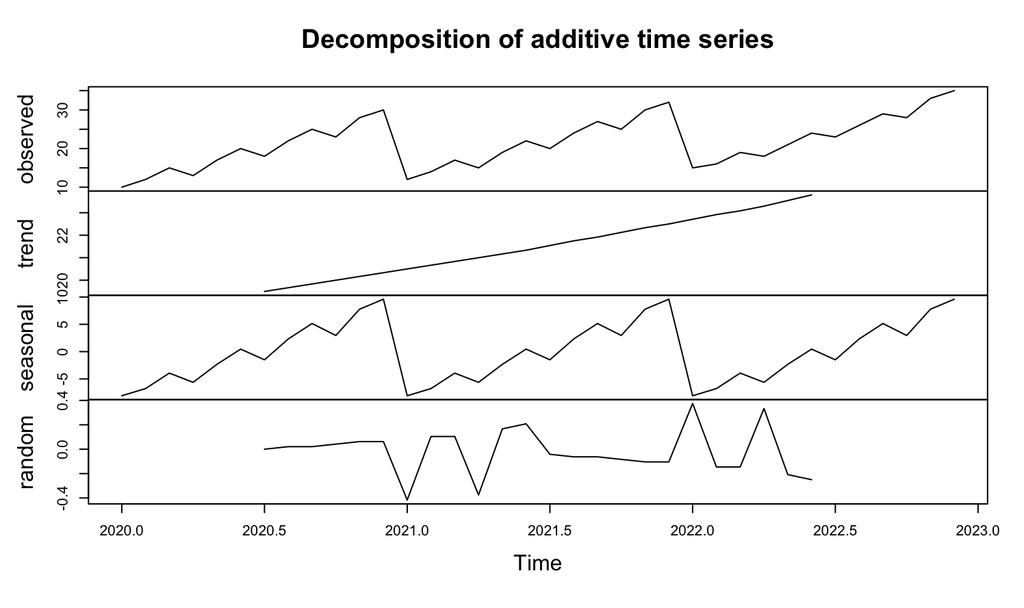

add.png

```r
        decomposed_sales_add <- decompose(sales_ts, type="additive")
        plot(decomposed_sales_add)

        # If multiplicative seems more appropriate
        # decomposed_sales_mult <- decompose(sales_ts, type="multiplicative")
        # plot(decomposed_sales_mult)
```

- **`stl(ts_data, s.window="periodic" or number)`:** “Seasonal and Trend decomposition using Loess.” More robust and flexible than `decompose()`.
- `s.window`: Controls the smoothness of the seasonal component.

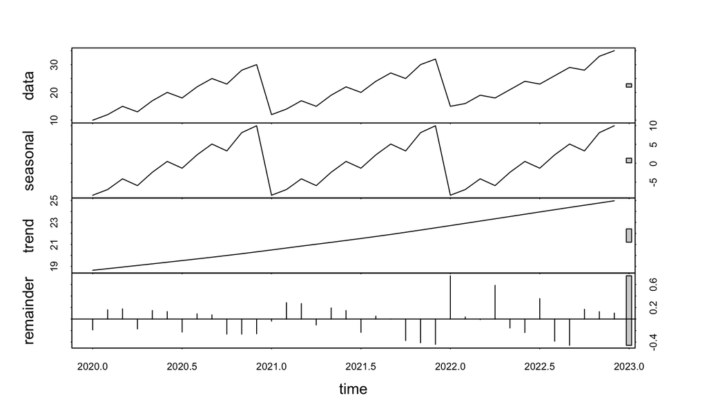

Rplot01.png

```r
        # install.packages("forecast") # stl is often used with forecast package utilities
        # library(forecast)
        stl_sales <- stl(sales_ts, s.window="periodic")
        plot(stl_sales)
        # autoplot(stl_sales) # if using forecast package
```

## Chapter Checkpoint

Before moving on, make sure you can answer these questions in words.

1. What makes time series data different from cross-sectional data?
2. Why is the order of observations important?
3. What can a time plot reveal before any formal model is fitted?
4. If a series has trend and seasonality, why might a simple average be misleading?

Short in-class task:

Choose one real example, such as monthly sales, daily temperature, exchange rates, or weekly website visits. State the time unit, the observed variable, and one question a time series model could help answer.